# Comparaison des variables provenant de seanoe et d’econum

Engels Guyliann

```r
# packages
SciViews::R
library(fst)
```

# 1 Desciption des données

```r
zs <- left_join(
  read("../../data/data_raw/features_native.csv.gz"),
  read("../../data/data_raw/taxa.csv.gz"),
  by = "objid")
en <- read_fst(path = "../../data/data_raw/econum_set.fst")
```

## 1.1 seanoe

Le dataset zs est composé des variables suivantes :

```r
names(zs)
```

```
 [1] "objid"      "area"       "mean"       "stddev"     "mode"       "min"        "max"        "perim."     "width"      "height"     "major"
[12] "minor"      "circ."      "feret"      "intden"     "median"     "skew"       "kurt"       "%area"      "area_exc"   "fractal"    "skelarea"
[23] "slope"      "histcum1"   "histcum2"   "histcum3"   "nb1"        "nb2"        "nb3"        "symetrieh"  "symetriev"  "symetriehc" "symetrievc"
[34] "convperim"  "convarea"   "fcons"      "thickr"     "elongation" "range"      "meanpos"    "cv"         "sr"         "perimferet" "perimmajor"
[45] "taxon"      "lineage"
```

Les groupes déterminés sont dénombré de la manière suivante :

```r
levels(as.factor(zs$taxon))
```

```
 [1] "Acantharea"                      "Acartiidae"                      "Actinopterygii"                  "Aglaura"
 [5] "Annelida"                        "artefact"                        "badfocus__artefact"              "badfocus__Copepoda"
 [9] "Bivalvia__Mollusca"              "Brachyura"                       "bubble"                          "Calanidae"
[13] "Calanoida"                       "Calocalanus pavo"                "calyptopsis"                     "Candaciidae"
[17] "Cavoliniidae"                    "Centropagidae"                   "Chaetognatha"                    "cirrus"
[21] "Copilia"                         "Corycaeidae"                     "Coscinodiscus"                   "Creseidae"
[25] "Ctenophora"                      "cyphonaute"                      "cypris"                          "Decapoda"
[29] "detritus"                        "Doliolida"                       "Echinoidea"                      "egg__Actinopterygii"
[33] "egg__Cavolinia_inflexa"          "egg__other"                      "ephyra"                          "Eucalanidae"
[37] "Euchaetidae"                     "Euchirella"                      "eudoxie__Abylopsis_tetragona"    "eudoxie__Diphyidae"
[41] "Evadne"                          "fiber__detritus"                 "Foraminifera"                    "Fritillariidae"
[45] "Gammaridea"                      "gonophore__Abylopsis_tetragona"  "gonophore__Diphyidae"            "Haloptilus"
[49] "Harpacticoida"                   "head"                            "Hyperiidea"                      "larvae__Annelida"
[53] "larvae__Crustacea"               "Limacidae"                       "Limacinidae"                     "Luciferidae"
[57] "megalopa"                        "metanauplii"                     "multiple__Copepoda"              "multiple__other"
[61] "nauplii__Cirripedia"             "nauplii__Crustacea"              "nectophore__Abylopsis_tetragona" "nectophore__Diphyidae"
[65] "nectophore__Physonectae"         "Neoceratium"                     "Noctiluca"                       "Obelia"
[69] "Oikopleuridae"                   "Oithonidae"                      "Oncaeidae"                       "Ophiuroidea"
[73] "Ostracoda"                       "part__Copepoda"                  "Penilia"                         "Phaeodaria"
[77] "Podon"                           "Pontellidae"                     "Pyrosomatida"                    "Rhincalanidae"
[81] "Rhopalonema"                     "Salpida"                         "Sapphirinidae"                   "scale"
[85] "Scyphozoa"                       "seaweed"                         "Spumellaria"                     "tail__Appendicularia"
[89] "tail__Chaetognatha"              "Temoridae"                       "Tomopteridae"                    "zoea__Decapoda"
[93] "zoea__Galatheidae"
```

## 1.2 econum

Le dataset en est composé des variables suivantes :

```r
names(en)
```

```
 [1] "ECD"        "Area"       "Mean"       "StdDev"     "Mode"       "Min"        "Max"        "X"          "Y"          "XM"         "YM"
[12] "Perim."     "BX"         "BY"         "Width"      "Height"     "Major"      "Minor"      "Angle"      "Circ."      "Feret"      "IntDen"
[23] "Median"     "Skew"       "Kurt"       "RawIntDen"  "FeretX"     "FeretY"     "FeretAngle" "MinFeret"   "AR"         "Round"      "Solidity"
[34] "XStart"     "YStart"     "Dil"        "Class"
```

Il s’agit d’un jeu de donnée exemple ne contenant que des fritillariidae et des scyphozoa_nd

# 2 Correspondance des variables

Une première approche est de comparer les noms des variables.

```r
zs$origin <- "villefr"
names(zs) -> names_zs

en$origin <- "econum"
names(en) %>% str_to_lower() -> t
names(en) <- t
names(en) -> names_en
```

```r
commun_names <- names_zs[names_zs %in% names_en]
commun_names <- commun_names[commun_names != "origin"]
```

17 variables ont un nom similaire listé ci-dessous :

```r
commun_names
```

```
 [1] "area"   "mean"   "stddev" "mode"   "min"    "max"    "perim." "width"  "height" "major"  "minor"  "circ."  "feret"  "intden" "median" "skew"
[17] "kurt"
```

Afin de ne pas comparer l’ensemble des groupes, un sous-ensemble va être réalisé

```r
#neco <- c("fritillariidae", "scyphozoa_nd")
#nsea <- c("Fritillariidae", "Scyphozoa")

 neco <- "fritillariidae"
 nsea <- "Fritillariidae"
(n_gr <- tibble(econum = neco, seanoe = nsea))
```

| econum | seanoe |
| --- | --- |
| fritillariidae | Fritillariidae |

```r
# filter dataset
eco <- en[en$class %in% neco, ]
vf <- zs[zs$taxon %in% nsea, ]

# change name taxon into class
colnames(vf)[colnames(vf) == "taxon"] <- "class"
```

```r
plot_descri <- function(data1, data2, var, ...){
  # variable
  vars <- c(var, "class", "origin")
  # filter
  dt1 <- data1[ , vars]
  dt2 <- data2[ , vars]
  # combine
  dt <- bind_rows(dt1, dt2)
  # plot
  boxplot(dt[[1]] ~ dt[[2]], data = dt, ylab = var, ...)
}
```

```
binding factor and character vector, coercing into character vectorbinding character and factor vector, coercing into character vector
```

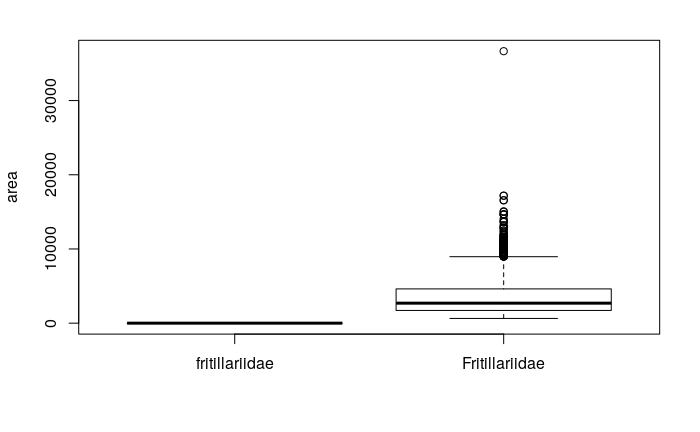

```
binding factor and character vector, coercing into character vectorbinding character and factor vector, coercing into character vector
```

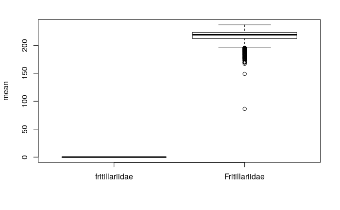

```
binding factor and character vector, coercing into character vectorbinding character and factor vector, coercing into character vector
```

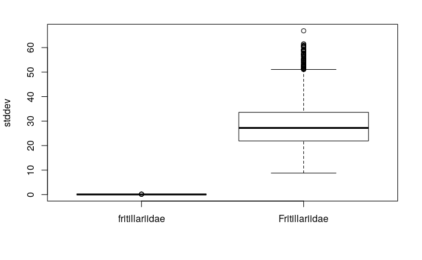

```
binding factor and character vector, coercing into character vectorbinding character and factor vector, coercing into character vector
```

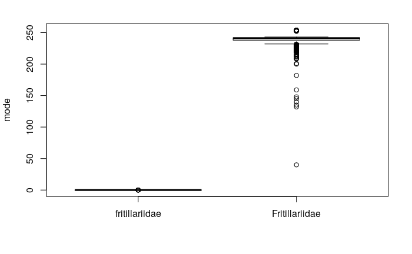

```
binding factor and character vector, coercing into character vectorbinding character and factor vector, coercing into character vector
```

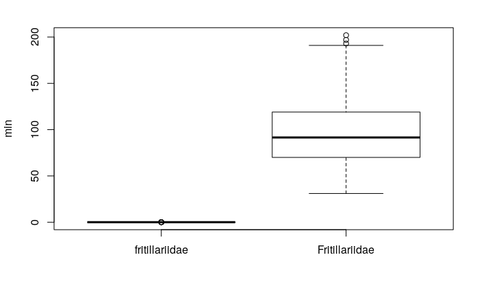

```
binding factor and character vector, coercing into character vectorbinding character and factor vector, coercing into character vector
```

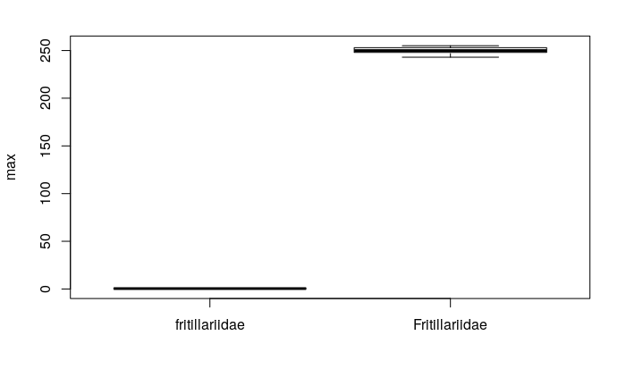

```
binding factor and character vector, coercing into character vectorbinding character and factor vector, coercing into character vector
```

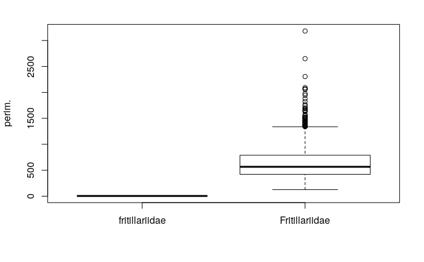

```
binding factor and character vector, coercing into character vectorbinding character and factor vector, coercing into character vector
```

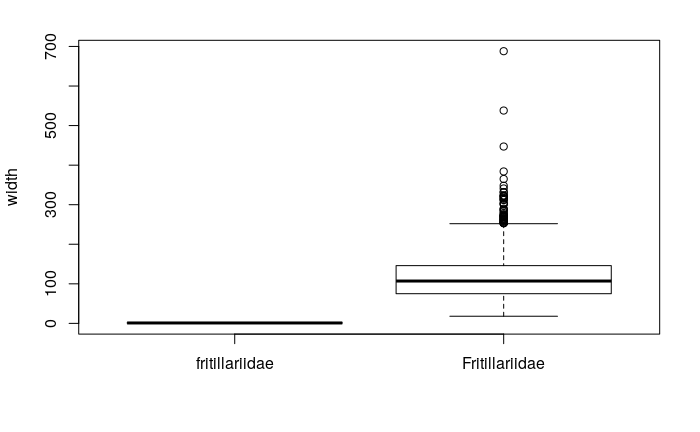

```
binding factor and character vector, coercing into character vectorbinding character and factor vector, coercing into character vector
```

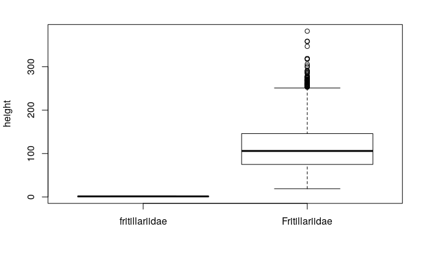

```
binding factor and character vector, coercing into character vectorbinding character and factor vector, coercing into character vector
```

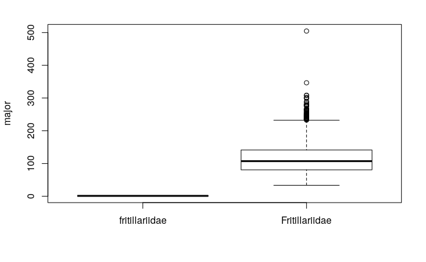

```
binding factor and character vector, coercing into character vectorbinding character and factor vector, coercing into character vector
```

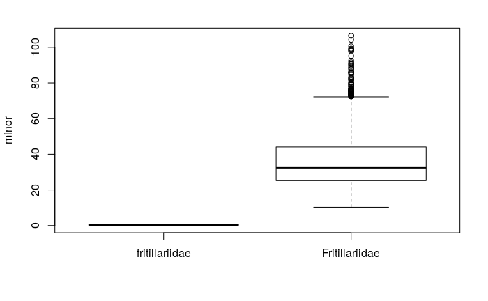

```
binding factor and character vector, coercing into character vectorbinding character and factor vector, coercing into character vector
```

```
binding factor and character vector, coercing into character vectorbinding character and factor vector, coercing into character vector
```

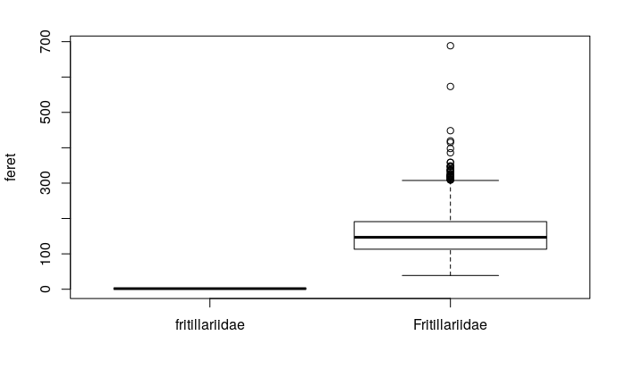

```
binding factor and character vector, coercing into character vectorbinding character and factor vector, coercing into character vector
```

```
binding factor and character vector, coercing into character vectorbinding character and factor vector, coercing into character vector
```

[2 more figures not shown]

```r
for(i in 1:length(commun_names)){
  plot_descri(data1 = eco, data2 = vf, var = commun_names[i])
}
```

## 2.1 Conversion des pixels en millimètres

```r
pix_conv <- 0.01058
(commun_names_pix <- c("perim.", "width", "height", "major", "minor", "feret"))
```

```
[1] "perim." "width"  "height" "major"  "minor"  "feret"
```

Dans les métadonnées liées aux fichiers **ZIDB**, on retrouve la valeur de calibration des pixels qui est de 0.01058. Avec ce valeurs, il est possible de convertir les variables suivantes exprimées en pixels perim., width, height, major, minor, feret

```r
source("../../R/pix_to_mm.R")
```

```r
vf %>%
  map_at(.at = commun_names_pix,.f =  pix_to_mm) -> vf
vf <- as_tibble(vf)
```

```r
for(i in 1:length(commun_names_pix)){
  plot_descri(data1 = eco, data2 = vf, var = commun_names_pix[i])
}
```

[output not shown]

```
binding factor and character vector, coercing into character vectorbinding character and factor vector, coercing into character vector
```

```
binding factor and character vector, coercing into character vectorbinding character and factor vector, coercing into character vector
```

```
binding factor and character vector, coercing into character vectorbinding character and factor vector, coercing into character vector
```

```
binding factor and character vector, coercing into character vectorbinding character and factor vector, coercing into character vector
```

```
binding factor and character vector, coercing into character vectorbinding character and factor vector, coercing into character vector
```

## 2.2 Conversion des pixels^2 en millimètre^2

La variable area est exprimé en $pixel^2$ dans le dataset de Villefranche alors qu’elle est exprimé en $mm^2$ dans le dataset d’ECONUN. En utilisant la valeur de conversion 0.01058 mise au carré nous convertissons efficacement la variable `area` pour donner 1.11936410^{-4}

```
binding factor and character vector, coercing into character vectorbinding character and factor vector, coercing into character vector
```

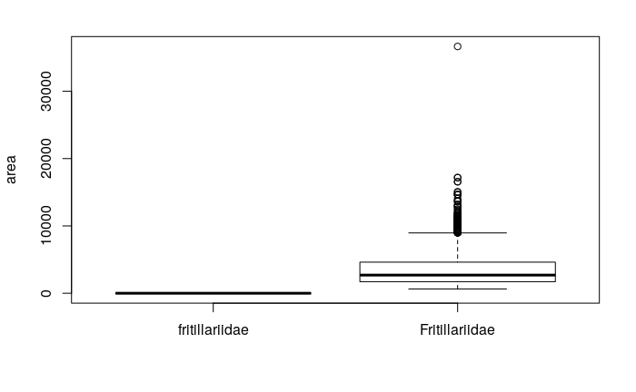

```r
plot_descri(data1 = eco, data2 = vf, var = "area")
```

```r
vf$area <- pix_to_mm(vf$area, pix_conv = 0.01058^2)
plot_descri(data1 = eco, data2 = vf, var = "area")
```

```
binding factor and character vector, coercing into character vectorbinding character and factor vector, coercing into character vector
```

## 2.3 Conversion des niveaux de gris

```r
source("../../R/grayscale_std.R")
```

Les variables ci-dessous expriment les nuances de gris :

```r
(gray <- c("mean", "stddev", "mode","min", "max", "median"))
```

```
[1] "mean"   "stddev" "mode"   "min"    "max"    "median"
```

```r
vf %>%
  map_at(.at = gray, .f = grayscale_std) %>% as_tibble() -> vf
```

```
binding factor and character vector, coercing into character vectorbinding character and factor vector, coercing into character vector
```

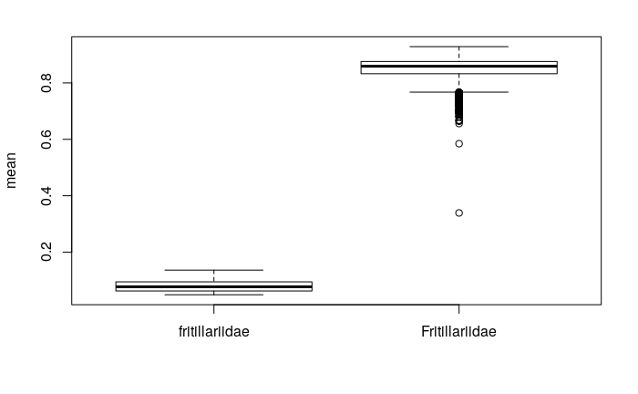

```
binding factor and character vector, coercing into character vectorbinding character and factor vector, coercing into character vector
```

```
binding factor and character vector, coercing into character vectorbinding character and factor vector, coercing into character vector
```

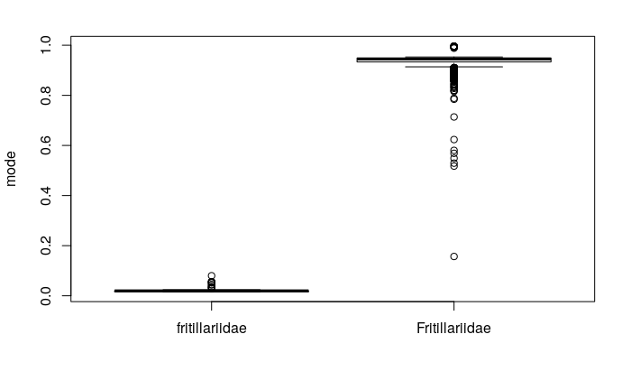

```
binding factor and character vector, coercing into character vectorbinding character and factor vector, coercing into character vector
```

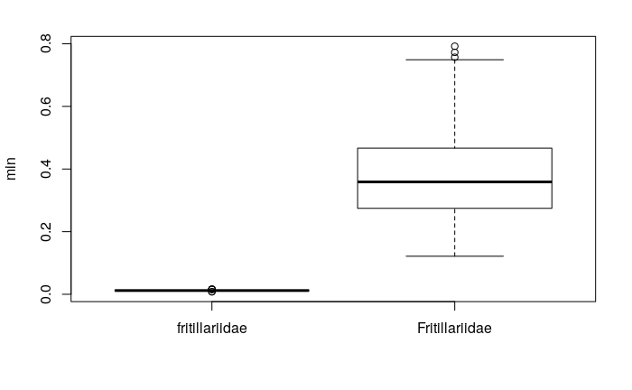

```
binding factor and character vector, coercing into character vectorbinding character and factor vector, coercing into character vector
```

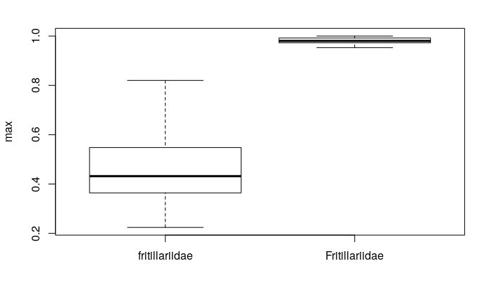

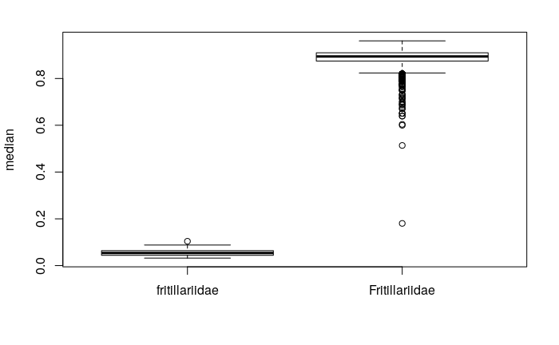

```r
for(i in 1:length(gray)){
  plot_descri(data1 = eco, data2 = vf, var = gray[i])
}
```

Malgré le fait d’avoir standardisé les valeurs entre 0 et 1, les valeurs ne correspondent toujours pas. Le jeu de données d’ECONUM est exprimé en densité optique (DO). Une valeur de 0 signifie que la particule est transparente alors qu’une valeur de 1 correspond à une particule très opaque. Le jeu de données de seanoe travaille en niveau de gris. Une valeur de 0 signifie que la particule est noire alors qu’une valeur de 255 (donc de 1 si l’on divise les variables par 255) en blanc.

```r
gray1 <- c("mean", "mode", "median", "min", "max")

vf %>%
  map_at(.at = gray1, .f = grayscale_convert) %>% as_tibble() -> vf
```

```
binding factor and character vector, coercing into character vectorbinding character and factor vector, coercing into character vector
```

```
binding factor and character vector, coercing into character vectorbinding character and factor vector, coercing into character vector
```

```
binding factor and character vector, coercing into character vectorbinding character and factor vector, coercing into character vector
```

```
binding factor and character vector, coercing into character vectorbinding character and factor vector, coercing into character vector
```

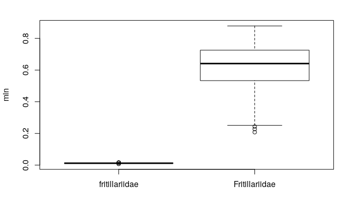

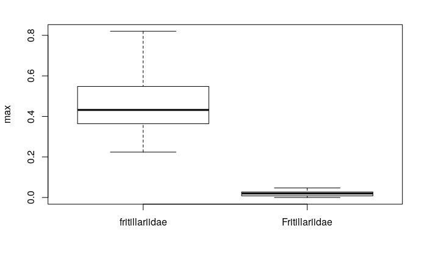

```r
for(i in 1:length(gray1)){
  plot_descri(data1 = eco, data2 = vf, var = gray1[i])
}
```

Concernant la valeur minimale et la valeur maximale, il est possible de simplement intervetir le min et le max.

```r
vf %>%
  dplyr::rename(min1 = min, max1 = max) %>%
  dplyr::rename(max = min1, min = max1) -> vf
```

```r
mm <- c("min", "max")
for(i in 1:length(mm)){
  plot_descri(data1 = eco, data2 = vf, var = mm[i])
}
```

[output not shown]

```
binding factor and character vector, coercing into character vectorbinding character and factor vector, coercing into character vector
```

## 2.4 skew

```r
vf$skew <- abs(vf$skew)
plot_descri(data1 = eco, data2 = vf, var = "skew")
```

[output not shown]

```
binding factor and character vector, coercing into character vectorbinding character and factor vector, coercing into character vector
```

# 3 Résumé des modifications

```r
for(i in 1:length(commun_names)){
  plot_descri(data1 = eco, data2 = vf, var = commun_names[i])
}
```

[output not shown]

[output not shown]

```
binding factor and character vector, coercing into character vectorbinding character and factor vector, coercing into character vector
```

```
binding factor and character vector, coercing into character vectorbinding character and factor vector, coercing into character vector
```

```
binding factor and character vector, coercing into character vectorbinding character and factor vector, coercing into character vector
```

```
binding factor and character vector, coercing into character vectorbinding character and factor vector, coercing into character vector
```

```
binding factor and character vector, coercing into character vectorbinding character and factor vector, coercing into character vector
```

[output not shown]

```
binding factor and character vector, coercing into character vectorbinding character and factor vector, coercing into character vector
```

```
binding factor and character vector, coercing into character vectorbinding character and factor vector, coercing into character vector
```

```
binding factor and character vector, coercing into character vectorbinding character and factor vector, coercing into character vector
```

```
binding factor and character vector, coercing into character vectorbinding character and factor vector, coercing into character vector
```

[output not shown]

```
binding factor and character vector, coercing into character vectorbinding character and factor vector, coercing into character vector
```

```
binding factor and character vector, coercing into character vectorbinding character and factor vector, coercing into character vector
```

```
binding factor and character vector, coercing into character vectorbinding character and factor vector, coercing into character vector
```

```
binding factor and character vector, coercing into character vectorbinding character and factor vector, coercing into character vector
```

# 4 Les variables calculés par la variable `zooimage::calcVars`

Le code de la fonction `calcVars()` donne une information sur les variables calculées

```r
zooimage::calcVars
```

[output not shown]

```r
vf %>%
  mutate(
    aspect_ratio = minor/major,
    range = max - min,
    mean_pos = (max-mean)/range,
    sd_norm = stddev/range,
    cv = stddev/mean *100,
    mean_dia = (major + minor)/2,
    meanf_dia = (feret + minor)/2,
    ecd = 2 * (area/3.14)^(1/2),
    transpi1 = 1-(ecd/mean_dia),
    transpi2 = 1-(ecd/meanf_dia),
    compactness = perim.^2/4/pi/area,
    pa = perim.^2/16 - area,
    elongation = ifelse(pa <= 0, 1, area/(perim./4 - pa^0.5)^2)) -> vf
```

Il est important de mettre en avant le fait que certaine variable ne sont pas calculables `CentBoxD`, `GrayCentBoxD`, `CentroidsD`.

Les variables calculées sur sont calculables sur les données

```r
eco %>%
  mutate(
    aspect_ratio = minor/major,
    range = max - min,
    mean_pos = (max-mean)/range,
    sd_norm = stddev/range,
    cv = stddev/mean *100,
    mean_dia = (major + minor)/2,
    meanf_dia = (feret + minor)/2,
    ecd = 2 * (area/3.14)^(1/2),
    transpi1 = 1-(ecd/mean_dia),
    transpi2 = 1-(ecd/meanf_dia),
    compactness = perim.^2/4/pi/area,
    pa = perim.^2/16 - area,
    elongation = ifelse(pa <= 0, 1, area/(perim./4 - pa^0.5)^2)) -> eco
```

# 5 Conclusions

```r
names(vf) -> names_vf
names(eco) -> names_eco
commun <- names_vf[names_vf %in% names_eco]
```

En conclusion, nous allons sélectionner les variables présents dans les deux jeux de données pour obtenir 32

```r
commun
```

```
 [1] "area"         "mean"         "stddev"       "mode"         "max"          "min"          "perim."       "width"        "height"
[10] "major"        "minor"        "circ."        "feret"        "intden"       "median"       "skew"         "kurt"         "elongation"
[19] "range"        "cv"           "class"        "origin"       "aspect_ratio" "mean_pos"     "sd_norm"      "mean_dia"     "meanf_dia"
[28] "ecd"          "transpi1"     "transpi2"     "compactness"  "pa"
```

[output not shown]

```
binding factor and character vector, coercing into character vectorbinding character and factor vector, coercing into character vector
```

```
binding factor and character vector, coercing into character vectorbinding character and factor vector, coercing into character vector
```

```
binding factor and character vector, coercing into character vectorbinding character and factor vector, coercing into character vector
```

```
binding factor and character vector, coercing into character vectorbinding character and factor vector, coercing into character vector
```

```
binding factor and character vector, coercing into character vectorbinding character and factor vector, coercing into character vector
```

```
binding factor and character vector, coercing into character vectorbinding character and factor vector, coercing into character vector
```

```
binding factor and character vector, coercing into character vectorbinding character and factor vector, coercing into character vector
```

[output not shown]

```
binding factor and character vector, coercing into character vectorbinding character and factor vector, coercing into character vector
```

```
binding factor and character vector, coercing into character vectorbinding character and factor vector, coercing into character vector
```

```
binding factor and character vector, coercing into character vectorbinding character and factor vector, coercing into character vector
```

```
binding factor and character vector, coercing into character vectorbinding character and factor vector, coercing into character vector
```

```
binding factor and character vector, coercing into character vectorbinding character and factor vector, coercing into character vector
```

```
binding factor and character vector, coercing into character vectorbinding character and factor vector, coercing into character vector
```

```
binding factor and character vector, coercing into character vectorbinding character and factor vector, coercing into character vector
```

[output not shown]

```
binding factor and character vector, coercing into character vectorbinding character and factor vector, coercing into character vector
```

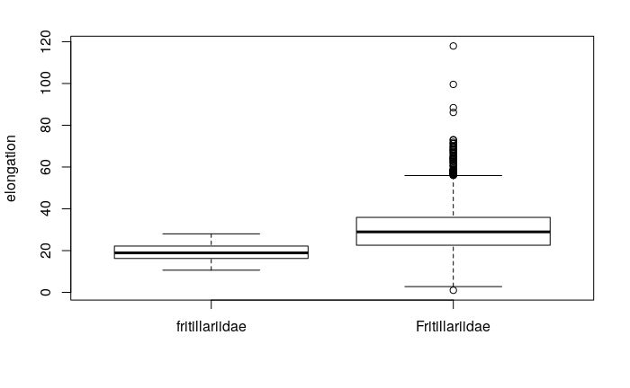

```
binding factor and character vector, coercing into character vectorbinding character and factor vector, coercing into character vector
```

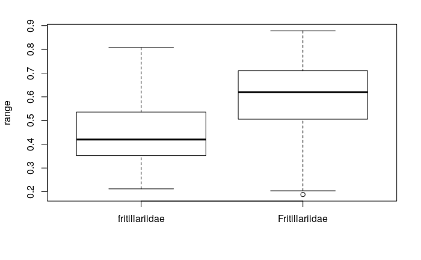

```
binding factor and character vector, coercing into character vectorbinding character and factor vector, coercing into character vector
```

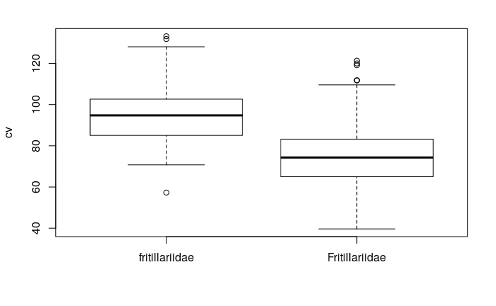

```
binding factor and character vector, coercing into character vectorbinding character and factor vector, coercing into character vector
```

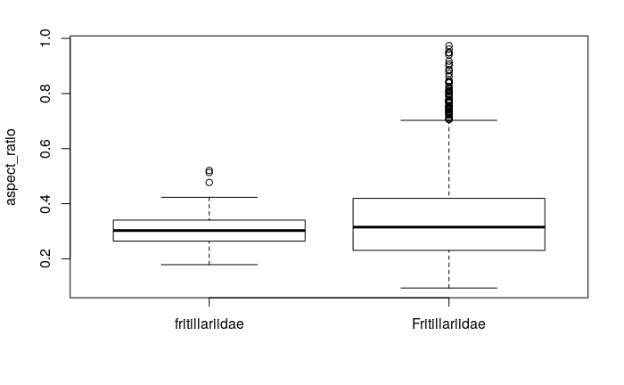

```
binding factor and character vector, coercing into character vectorbinding character and factor vector, coercing into character vector
```

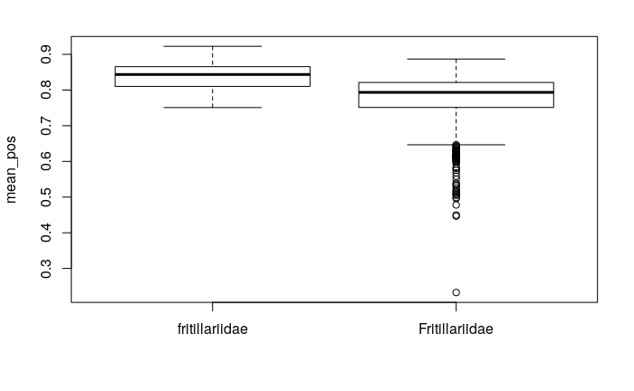

```
binding factor and character vector, coercing into character vectorbinding character and factor vector, coercing into character vector
```

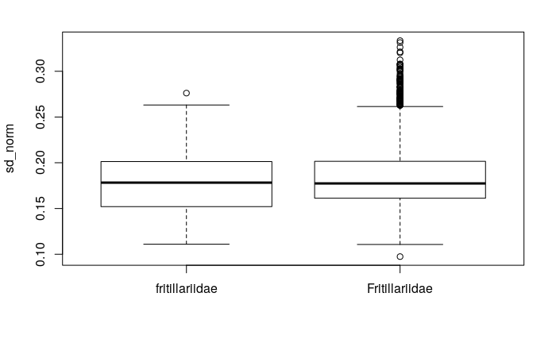

```
binding factor and character vector, coercing into character vectorbinding character and factor vector, coercing into character vector
```

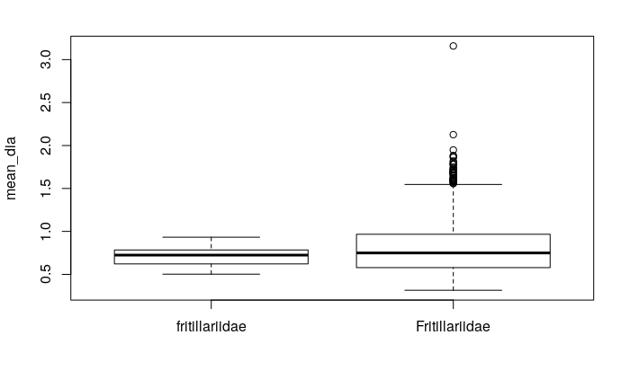

```
binding factor and character vector, coercing into character vectorbinding character and factor vector, coercing into character vector
```

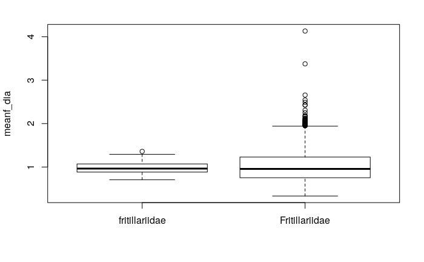

```
binding factor and character vector, coercing into character vectorbinding character and factor vector, coercing into character vector
```

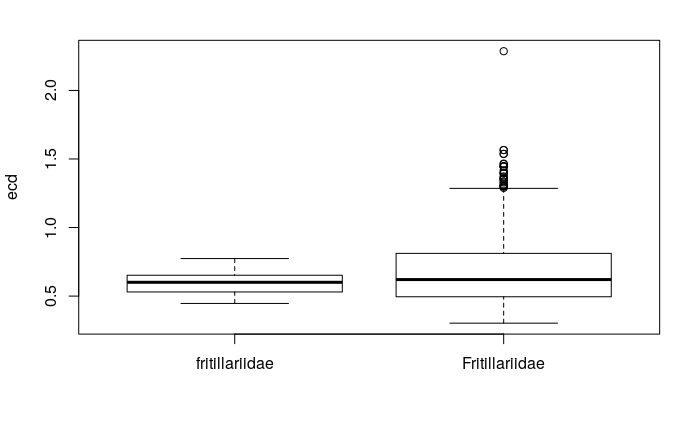

```
binding factor and character vector, coercing into character vectorbinding character and factor vector, coercing into character vector
```

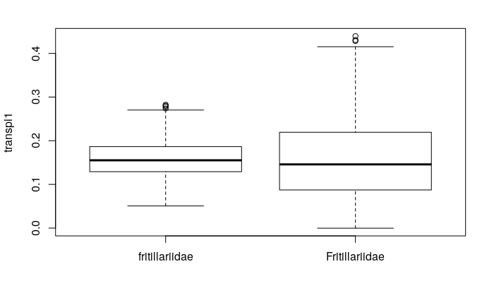

```
binding factor and character vector, coercing into character vectorbinding character and factor vector, coercing into character vector
```

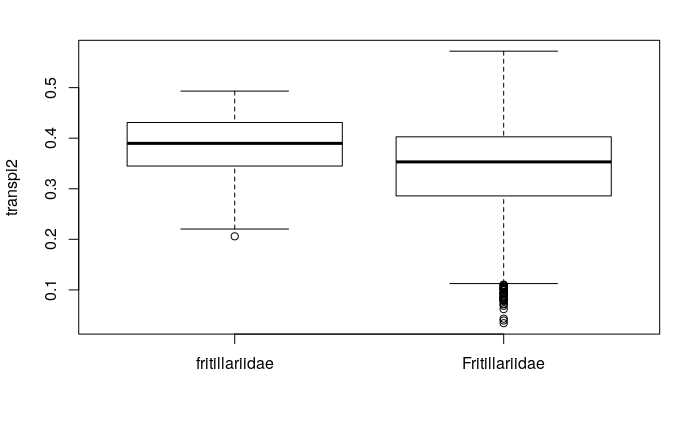

```
binding factor and character vector, coercing into character vectorbinding character and factor vector, coercing into character vector
```

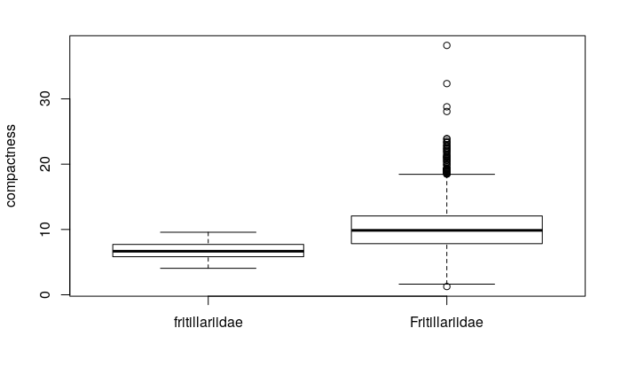

[1 more figures not shown]

```r
co <- commun[commun != "class"]
co <- co[co != "origin"]

for(i in 1:length(co)){

  plot_descri(data1 = eco, data2 = vf, var = co[i])
}
```